# How to Manufacture Your Personality to Gain Friends and Second Dates: A Data-Driven Field Guide for Pathetic People by Pathetic People

Group members: Beau, Richard, Saad, Kevin

```r
library(data.table)
```

# Importing the data

(credit: Beau and Richard)

Speed Dating dataset: https://www.kaggle.com/annavictoria/speed-dating-experiment

Each row of the data represents one date between two people. The primary key is one of the participants in the date, so for each date there are two rows in the dataset.

```r
# This works if you do the following:
# stick the csv file in the same directory as this Rmd
# in RStudio, go to Session -> Set Work Directory -> To Source File location
# this expects only one csv to be in the directory
project.dir <- getwd()
setwd(project.dir)
csv_file <- list.files(file.path(project.dir), pattern="*.csv", full.names=TRUE)
full_data <- fread(file.path(csv_file))


full_data[,c("race_o","field_cd", "race", "goal", "date", "go_out", "career_c", "met", "dec", "length", "numdat_2", "gender", "condtn")] <- lapply(full_data[,c("race_o","field_cd", "race", "goal", "date", "go_out", "career_c", "met", "dec", "length", "numdat_2", "gender", "condtn")], factor)

#income, tuition, and mn_sat have NA values so they aren't numeric

nrow(full_data[complete.cases(full_data[ , c("income","tuition","mn_sat")]),])
```

```
## [1] 8378
```

```r
nrow(full_data)
```

```
## [1] 8378
```

```r
#we could look at subset? is there a reason that people left off this information?

#full_data <- nrow(full_data[complete.cases(full_data[ , c("income")]),])
#nrow(full_data[complete.cases(full_data[ , c("mn_sat", "income")]),])
#nrow(full_data[complete.cases(full_data[ , c("tuition", "income")]),])
```

Save/Load current state for easy continuation (credit: Kev)

```r
#setwd()
#saveRDS(full_data, file="full_speed_dating.rds")
#full_data <- readRDS("full_speed_dating.rds")
```

# Predicting rate of people liking you with constant fields

(credit: Beau and Richard)

The variable ‘dec_o’ encodes whether the other person in the date decided they would like a second date with you (1 for yes, 0 for no). We decided to use this as the response variable instead of ‘match’ because ‘match’ means that both people mutually liked each other. In particular, for each participant, we took the mean of ‘dec_o’ as a proxy for desireable-ness.

We defined a new table ‘const_attribs’ which represents the constant attributes of the participants. For example, from one date to another your age, field of study, and gender do not change. We wanted to see whether we can predict desirable-ness from your non-subjective attributes.

However, we could not predict anything with this lm (R^2 = 0.14).

```r
#  rate that people decide they wanted to date you after the speed date
# aggregate certain variables for each individual (avg's of attracitness, intelligence score ... etc. that others gave after meeting)

desirableness <- aggregate(dec_o ~ iid, full_data, mean)


# create subset with the fields that remain constant for an individual (regardless of the meeting)
const_attribs <- full_data[, c("iid", "gender","age", "field_cd", "mn_sat", "tuition", "imprace", "income", "goal", "date", "go_out", "career_c", "match_es","sports", "tvsports", "exercise", "dining", "museums", "art", "hiking", "gaming", "clubbing", "reading", "tv", "theater", "movies", "concerts", "music", "shopping", "yoga")]

# this resulting table has lots of duplicated data
# remove duplicates so there is only one obs per person
const_attribs <- const_attribs[!duplicated(const_attribs),]

# binding back together w desirableness
const_attribs <- merge(desirableness, const_attribs, by="iid")

# merges list of dataframes into a single df. removes iid as a predictor.
full_const_fit <- lm(dec_o ~ .-iid, data = na.omit(const_attribs))  # TODO find reduced model in git commit history
```

After we reduced the insignificant predictors in this model, it had an adjusted R^2 of just 0.14.

# Predicting rate of people liking you with constant fields and partner-rankings

We augmented this linear model using the rankings from your partners: how attractive, sincere, intelligent, fun, and amibiotous your partners percieved you to be durin the 4 minute speed-date. In particular, for each individual we took the mean rating by their partners.

```r
#additional explanitory variables. note that after this point, attr_o, sinc_o, etc are
# now aggregated means
attractive <- aggregate(attr_o ~ iid, full_data, mean)
sincere <- aggregate(sinc_o ~ iid, full_data, mean)
intelligent <- aggregate(intel_o ~ iid, full_data, mean)
fun <- aggregate(fun_o ~ iid, full_data, mean)
ambitious <- aggregate( amb_o ~ iid, full_data, mean) # this was assigned incorrectly.. do any of the analyses change in model prediction section?
attractive <- aggregate(attr_o ~ iid, full_data, mean)
likeability <- aggregate(like_o ~ iid,full_data, mean)

augmented_attribs <- Reduce(function(x, y) merge(x, y, all=TRUE), list(attractive, sincere, intelligent, fun, ambitious, const_attribs, desirableness))
```

We removed a few columns that had pesky numerical values. We will come back and probably add these back in after fixing that.

```r
# remove fields that consist of mostly NA's
# these are tuition, SAT, and predicted income
augmented_attribs <- augmented_attribs[, -which(names(augmented_attribs) %in% c("tuition", "mn_sat", "income")) ]
# fit a full model
# NOTE: we removed  NAs, remember to add these rows back later if we reduce the model
full_augmented_fit <- lm(dec_o ~ .-iid, data = na.omit(augmented_attribs))
summary(full_augmented_fit)
```

```
##
## Call:
## lm(formula = dec_o ~ . - iid, data = na.omit(augmented_attribs))
##
## Residuals:
##      Min       1Q   Median       3Q      Max
## -0.36520 -0.08822 -0.00524  0.08182  0.42020
##
## Coefficients: (1 not defined because of singularities)
##               Estimate Std. Error t value Pr(>|t|)
## (Intercept) -0.4284378  0.1370053  -3.127   0.0019 **
## attr_o       0.1205966  0.0087454  13.790  < 2e-16 ***
## sinc_o      -0.0186533  0.0143825  -1.297   0.1954
## intel_o      0.0103971  0.0214202   0.485   0.6277
## fun_o        0.0632598  0.0102762   6.156 1.85e-09 ***
## amb_o       -0.0041783  0.0153858  -0.272   0.7861
## gender1     -0.0423535  0.0193924  -2.184   0.0296 *
## age         -0.0031902  0.0020122  -1.585   0.1137
## field_cd2   -0.0153482  0.0709494  -0.216   0.8288
## field_cd3    0.0024820  0.0615646   0.040   0.9679
## field_cd4    0.0367259  0.0818159   0.449   0.6538
## field_cd5   -0.0126334  0.0596134  -0.212   0.8323
## field_cd6   -0.0051862  0.0677090  -0.077   0.9390
## field_cd7   -0.0047066  0.0652417  -0.072   0.9425
## field_cd8    0.0374003  0.0572785   0.653   0.5142
## field_cd9   -0.0527831  0.0614286  -0.859   0.3907
## field_cd10  -0.0212944  0.0599661  -0.355   0.7227
## field_cd11  -0.0750507  0.0681438  -1.101   0.2714
## field_cd12  -0.0942384  0.1590153  -0.593   0.5538
## field_cd13  -0.0741860  0.0602051  -1.232   0.2186
## field_cd14   0.0536081  0.0827754   0.648   0.5176
## field_cd15   0.0252545  0.0764637   0.330   0.7414
## field_cd16   0.2532089  0.0923661   2.741   0.0064 **
## field_cd17  -0.0633854  0.1475603  -0.430   0.6678
## field_cd18  -0.0232298  0.1168520  -0.199   0.8425
## imprace     -0.0009147  0.0026118  -0.350   0.7264
## goal2       -0.0085901  0.0166963  -0.514   0.6072
## goal3        0.0133193  0.0264685   0.503   0.6151
## goal4       -0.0073760  0.0391689  -0.188   0.8507
## goal5        0.0029902  0.0303432   0.099   0.9215
```

[output cut: 38 more lines]

```
## clubbing     0.0008773  0.0030188   0.291   0.7715
## reading     -0.0033231  0.0038386  -0.866   0.3872
## tv           0.0032676  0.0035806   0.913   0.3620
## theater     -0.0008898  0.0045579  -0.195   0.8453
## movies      -0.0043294  0.0051919  -0.834   0.4049
## concerts     0.0043669  0.0046875   0.932   0.3521
## music       -0.0034101  0.0050617  -0.674   0.5009
## shopping    -0.0019802  0.0034887  -0.568   0.5706
## yoga        -0.0063201  0.0028292  -2.234   0.0261 *
## ---
## Signif. codes:  0 '***' 0.001 '**' 0.01 '*' 0.05 '.' 0.1 ' ' 1
##
## Residual standard error: 0.1391 on 391 degrees of freedom
## Multiple R-squared:  0.7086, Adjusted R-squared:  0.6527
## F-statistic: 12.68 on 75 and 391 DF,  p-value: < 2.2e-16
```

The full model has an adj-R^2 of 0.65 on 75 predictor variables. In order to reduce our model, we ran a stepwise AIC.

```r
library(MASS)
step <- stepAIC(full_augmented_fit, direction="both")
```

```
## Start:  AIC=-1773.21
## dec_o ~ (iid + attr_o + sinc_o + intel_o + fun_o + amb_o + gender +
##     age + field_cd + imprace + goal + date + go_out + career_c +
##     match_es + sports + tvsports + exercise + dining + museums +
##     art + hiking + gaming + clubbing + reading + tv + theater +
##     movies + concerts + music + shopping + yoga) - iid
##
##            Df Sum of Sq     RSS     AIC
## - goal      5    0.0154  7.5826 -1782.3
## - date      6    0.0700  7.6372 -1780.9
## - go_out    6    0.1213  7.6885 -1777.8
## - art       1    0.0001  7.5673 -1775.2
## - dining    1    0.0001  7.5673 -1775.2
## - theater   1    0.0007  7.5679 -1775.2
## - amb_o     1    0.0014  7.5686 -1775.1
## - clubbing  1    0.0016  7.5688 -1775.1
## - imprace   1    0.0024  7.5696 -1775.1
## - match_es  1    0.0026  7.5698 -1775.0
## - sports    1    0.0032  7.5704 -1775.0
## - intel_o   1    0.0046  7.5718 -1774.9
## - gaming    1    0.0049  7.5721 -1774.9
## - shopping  1    0.0062  7.5734 -1774.8
## - music     1    0.0088  7.5760 -1774.7
## - movies    1    0.0135  7.5807 -1774.4
## - museums   1    0.0139  7.5811 -1774.3
## - exercise  1    0.0143  7.5815 -1774.3
## - hiking    1    0.0144  7.5816 -1774.3
## - reading   1    0.0145  7.5817 -1774.3
## - tv        1    0.0161  7.5833 -1774.2
## - concerts  1    0.0168  7.5840 -1774.2
## <none>                   7.5672 -1773.2
## - sinc_o    1    0.0326  7.5998 -1773.2
## - age       1    0.0486  7.6158 -1772.2
## - field_cd 16    0.5554  8.1226 -1772.1
## - gender    1    0.0923  7.6595 -1769.5
## - yoga      1    0.0966  7.6638 -1769.3
## - tvsports  1    0.1111  7.6783 -1768.4
## - career_c 15    0.9183  8.4855 -1749.7
## - fun_o     1    0.7334  8.3006 -1732.0
## - attr_o    1    3.6802 11.2474 -1590.1
```

[output cut: 928 more lines]

```
## + intel_o   1    0.0020  8.4827 -1823.9
## + dining    1    0.0010  8.4838 -1823.8
## + tv        1    0.0008  8.4839 -1823.8
## + sports    1    0.0007  8.4840 -1823.8
## + imprace   1    0.0005  8.4842 -1823.8
## + reading   1    0.0003  8.4844 -1823.8
## + amb_o     1    0.0002  8.4846 -1823.8
## + theater   1    0.0002  8.4846 -1823.8
## - tvsports  1    0.1338  8.6185 -1820.5
## + go_out    6    0.1016  8.3832 -1819.4
## + date      6    0.0527  8.4320 -1816.7
## + goal      5    0.0059  8.4788 -1816.1
## - career_c 16    0.9151  9.3999 -1809.9
## - fun_o     1    0.8873  9.3720 -1781.3
## - attr_o    1    4.5172 13.0019 -1628.4
```

```r
step$anova # display results
```

```
## Stepwise Model Path
## Analysis of Deviance Table
##
## Initial Model:
## dec_o ~ (iid + attr_o + sinc_o + intel_o + fun_o + amb_o + gender +
##     age + field_cd + imprace + goal + date + go_out + career_c +
##     match_es + sports + tvsports + exercise + dining + museums +
##     art + hiking + gaming + clubbing + reading + tv + theater +
##     movies + concerts + music + shopping + yoga) - iid
##
## Final Model:
## dec_o ~ attr_o + fun_o + gender + age + career_c + tvsports +
##     yoga
##
##
##          Step Df     Deviance Resid. Df Resid. Dev       AIC
## 1                                   391   7.567203 -1773.210
## 2      - goal  5 1.539654e-02       396   7.582600 -1782.261
## 3      - date  6 7.484334e-02       402   7.657443 -1789.674
## 4    - go_out  6 1.260687e-01       408   7.783512 -1794.048
## 5  - field_cd 16 5.162036e-01       424   8.299715 -1796.060
## 6     - amb_o  1 6.261291e-06       425   8.299722 -1798.060
## 7    - dining  1 5.409194e-05       426   8.299776 -1800.057
## 8   - imprace  1 5.688824e-04       427   8.300345 -1802.025
## 9    - sports  1 9.320928e-04       428   8.301277 -1803.973
## 10   - hiking  1 8.642941e-04       429   8.302141 -1805.924
## 11       - tv  1 1.656778e-03       430   8.303798 -1807.831
## 12 - clubbing  1 1.512689e-03       431   8.305311 -1809.746
## 13  - museums  1 2.893222e-03       432   8.308204 -1811.583
## 14   - movies  1 3.070824e-03       433   8.311275 -1813.411
## 15  - intel_o  1 3.687421e-03       434   8.314962 -1815.203
## 16  - reading  1 3.712978e-03       435   8.318675 -1816.995
## 17 - exercise  1 7.063253e-03       436   8.325738 -1818.599
## 18 - match_es  1 8.569040e-03       437   8.334307 -1820.118
## 19 - shopping  1 9.869137e-03       438   8.344176 -1821.565
## 20   - gaming  1 1.906035e-02       439   8.363237 -1822.500
## 21  - theater  1 1.937799e-02       440   8.382615 -1823.419
## 22 - concerts  1 1.872411e-02       441   8.401339 -1824.377
## 23    - music  1 1.833370e-02       442   8.419673 -1825.359
## 24      - art  1 3.188745e-02       443   8.451560 -1825.594
## 25   - sinc_o  1 3.317171e-02       444   8.484732 -1825.764
```

Reducing our desirableness model based on our stepAIC:

```r
# the stepAIC returned this model as these as our optimal predictors
# dec_o ~ attr_o + fun_o + gender + age + career_c + tvsports + yoga
# dec_o, attr_o, fun_o here is the mean of dec_o, attr_o, fun_o reported by partners
reduced_augmented_fit <- lm(dec_o ~ attr_o + fun_o + gender + age + career_c + tvsports + yoga, data = na.omit(augmented_attribs))

summary(reduced_augmented_fit)
```

```
##
## Call:
## lm(formula = dec_o ~ attr_o + fun_o + gender + age + career_c +
##     tvsports + yoga, data = na.omit(augmented_attribs))
##
## Residuals:
##      Min       1Q   Median       3Q      Max
## -0.41470 -0.08912 -0.00218  0.08472  0.43041
##
## Coefficients:
##              Estimate Std. Error t value Pr(>|t|)
## (Intercept) -0.577780   0.071593  -8.070 6.62e-15 ***
## attr_o       0.120673   0.007849  15.375  < 2e-16 ***
## fun_o        0.061483   0.009023   6.814 3.11e-11 ***
## gender1     -0.028455   0.014767  -1.927  0.05464 .
## age         -0.002806   0.001764  -1.591  0.11243
## career_c2    0.018852   0.026269   0.718  0.47336
## career_c3   -0.108143   0.041151  -2.628  0.00889 **
## career_c4    0.001997   0.036428   0.055  0.95630
## career_c5   -0.009262   0.044519  -0.208  0.83528
## career_c6   -0.034336   0.031669  -1.084  0.27886
## career_c7    0.004894   0.026364   0.186  0.85283
## career_c8   -0.462684   0.101430  -4.562 6.58e-06 ***
## career_c9   -0.018413   0.034970  -0.527  0.59878
## career_c10  -0.002457   0.037142  -0.066  0.94728
## career_c11  -0.039991   0.045415  -0.881  0.37903
## career_c12  -0.248414   0.101162  -2.456  0.01445 *
## career_c13   0.056597   0.066072   0.857  0.39213
## career_c14   0.208049   0.140941   1.476  0.14062
## career_c15   0.096691   0.074230   1.303  0.19339
## career_c16   0.040248   0.101192   0.398  0.69101
## career_c17  -0.071265   0.140462  -0.507  0.61215
## tvsports    -0.006275   0.002372  -2.646  0.00844 **
## yoga        -0.004584   0.002469  -1.857  0.06398 .
## ---
## Signif. codes:  0 '***' 0.001 '**' 0.01 '*' 0.05 '.' 0.1 ' ' 1
##
## Residual standard error: 0.1382 on 444 degrees of freedom
## Multiple R-squared:  0.6732, Adjusted R-squared:  0.6571
## F-statistic: 41.58 on 22 and 444 DF,  p-value: < 2.2e-16
```

```r
anova(reduced_augmented_fit, lm(dec_o ~ attr_o + fun_o + gender + age + tvsports + yoga, data = na.omit(augmented_attribs)) )
```

```
## Analysis of Variance Table
##
## Model 1: dec_o ~ attr_o + fun_o + gender + age + career_c + tvsports +
##     yoga
## Model 2: dec_o ~ attr_o + fun_o + gender + age + tvsports + yoga
##   Res.Df    RSS  Df Sum of Sq     F    Pr(>F)
## 1    444 8.4847
## 2    460 9.3999 -16  -0.91513 2.993 9.112e-05 ***
## ---
## Signif. codes:  0 '***' 0.001 '**' 0.01 '*' 0.05 '.' 0.1 ' ' 1
```

The p-value of the F test indicates the model with career significantly reduces the sum of squares error, so we will keep them it in model.

# Checking for associations between variables

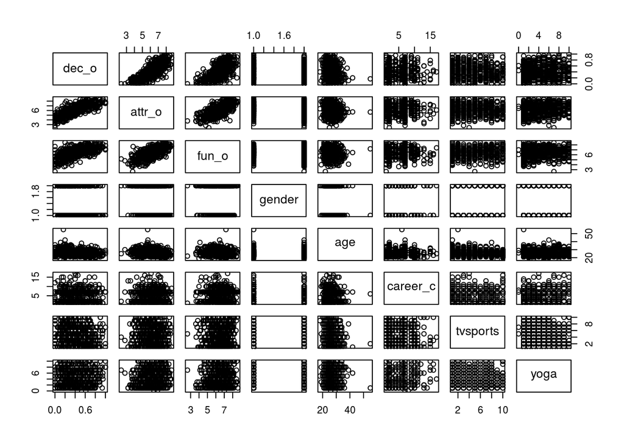

```r
pairs(augmented_attribs[,c("dec_o", "attr_o", "fun_o", "gender","age", "career_c", "tvsports","yoga")])
```

We saw some multicollinearity with attr_o and fun_o so we decided to include an interaction term in our model and compared it inside ANOVA.

```r
anova(reduced_augmented_fit, lm(dec_o ~ attr_o + fun_o + career_c + gender + age + tvsports + yoga + attr_o*fun_o, data = na.omit(augmented_attribs)) )
```

```
## Analysis of Variance Table
##
## Model 1: dec_o ~ attr_o + fun_o + gender + age + career_c + tvsports +
##     yoga
## Model 2: dec_o ~ attr_o + fun_o + career_c + gender + age + tvsports +
##     yoga + attr_o * fun_o
##   Res.Df    RSS Df Sum of Sq     F   Pr(>F)
## 1    444 8.4847
## 2    443 8.2983  1   0.18648 9.955 0.001713 **
## ---
## Signif. codes:  0 '***' 0.001 '**' 0.01 '*' 0.05 '.' 0.1 ' ' 1
```

```r
# it appears that fun_o and attractiveness_o have a linear relationship with our response AND (maybe) each other
```

Here, we find that the model with the interaction term reduces the sums of squares better than the reduced model without it.

```r
reduced_augmented_fit<-lm(dec_o ~ attr_o + fun_o + career_c + gender + age + tvsports + yoga + attr_o*fun_o, data = na.omit(augmented_attribs))

summary(reduced_augmented_fit)
```

```
##
## Call:
## lm(formula = dec_o ~ attr_o + fun_o + career_c + gender + age +
##     tvsports + yoga + attr_o * fun_o, data = na.omit(augmented_attribs))
##
## Residuals:
##      Min       1Q   Median       3Q      Max
## -0.43265 -0.08633 -0.00321  0.08104  0.44211
##
## Coefficients:
##               Estimate Std. Error t value Pr(>|t|)
## (Intercept)  -0.010399   0.193292  -0.054  0.95712
## attr_o        0.019333   0.033046   0.585  0.55882
## fun_o        -0.030650   0.030537  -1.004  0.31606
## career_c2     0.025153   0.026085   0.964  0.33544
## career_c3    -0.104333   0.040760  -2.560  0.01081 *
## career_c4     0.008133   0.036118   0.225  0.82195
## career_c5    -0.008849   0.044077  -0.201  0.84098
## career_c6    -0.024113   0.031522  -0.765  0.44470
## career_c7     0.008893   0.026133   0.340  0.73379
## career_c8    -0.492488   0.100866  -4.883 1.46e-06 ***
## career_c9    -0.012222   0.034678  -0.352  0.72468
## career_c10    0.003635   0.036824   0.099  0.92142
## career_c11   -0.026998   0.045152  -0.598  0.55019
## career_c12   -0.235326   0.100243  -2.348  0.01934 *
## career_c13    0.039950   0.065628   0.609  0.54301
## career_c14    0.211939   0.139547   1.519  0.12953
## career_c15    0.106547   0.073559   1.448  0.14820
## career_c16    0.057115   0.100329   0.569  0.56946
## career_c17   -0.055345   0.139158  -0.398  0.69103
## gender1      -0.031970   0.014663  -2.180  0.02976 *
## age          -0.002569   0.001748  -1.470  0.14232
## tvsports     -0.006058   0.002349  -2.579  0.01024 *
## yoga         -0.004803   0.002445  -1.964  0.05012 .
## attr_o:fun_o  0.015823   0.005015   3.155  0.00171 **
## ---
## Signif. codes:  0 '***' 0.001 '**' 0.01 '*' 0.05 '.' 0.1 ' ' 1
##
## Residual standard error: 0.1369 on 443 degrees of freedom
## Multiple R-squared:  0.6804, Adjusted R-squared:  0.6638
## F-statistic: 41.01 on 23 and 443 DF,  p-value: < 2.2e-16
```

```r
summary(lm(dec_o ~ attr_o + fun_o + gender + age + career_c + tvsports +
    concerts + music + yoga + attr_o:fun_o, data = na.omit(augmented_attribs)))
```

```
##
## Call:
## lm(formula = dec_o ~ attr_o + fun_o + gender + age + career_c +
##     tvsports + concerts + music + yoga + attr_o:fun_o, data = na.omit(augmented_attribs))
##
## Residuals:
##      Min       1Q   Median       3Q      Max
## -0.41960 -0.08858 -0.00191  0.08020  0.43427
##
## Coefficients:
##               Estimate Std. Error t value Pr(>|t|)
## (Intercept)   0.004220   0.194249   0.022  0.98268
## attr_o        0.017285   0.033075   0.523  0.60151
## fun_o        -0.031902   0.030538  -1.045  0.29675
## gender1      -0.030351   0.014709  -2.063  0.03965 *
## age          -0.002535   0.001747  -1.451  0.14750
## career_c2     0.025690   0.026073   0.985  0.32502
## career_c3    -0.104504   0.040767  -2.563  0.01069 *
## career_c4     0.008371   0.036086   0.232  0.81666
## career_c5    -0.012965   0.044136  -0.294  0.76908
## career_c6    -0.023914   0.031542  -0.758  0.44877
## career_c7     0.010462   0.026168   0.400  0.68950
## career_c8    -0.490645   0.101018  -4.857 1.66e-06 ***
## career_c9    -0.011240   0.034662  -0.324  0.74588
## career_c10    0.007169   0.036860   0.194  0.84588
## career_c11   -0.028874   0.045132  -0.640  0.52265
## career_c12   -0.238328   0.100169  -2.379  0.01777 *
## career_c13    0.043373   0.065639   0.661  0.50910
## career_c14    0.218969   0.139484   1.570  0.11717
## career_c15    0.111603   0.073647   1.515  0.13039
## career_c16    0.071038   0.100622   0.706  0.48056
## career_c17   -0.062551   0.139487  -0.448  0.65406
## tvsports     -0.006258   0.002369  -2.642  0.00854 **
## concerts      0.006323   0.004024   1.571  0.11683
## music        -0.006605   0.004656  -1.418  0.15676
## yoga         -0.005361   0.002520  -2.127  0.03394 *
## attr_o:fun_o  0.016216   0.005021   3.230  0.00133 **
## ---
## Signif. codes:  0 '***' 0.001 '**' 0.01 '*' 0.05 '.' 0.1 ' ' 1
##
## Residual standard error: 0.1367 on 441 degrees of freedom
## Multiple R-squared:  0.6824, Adjusted R-squared:  0.6644
## F-statistic: 37.91 on 25 and 441 DF,  p-value: < 2.2e-16
```

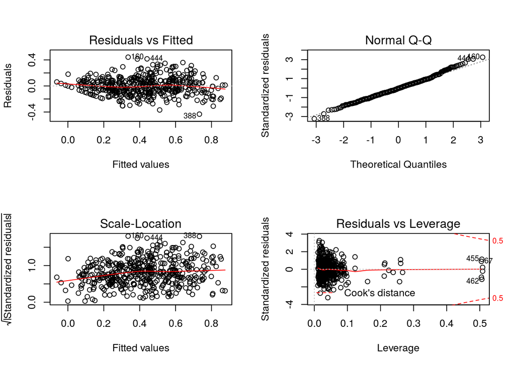

```r
par(mfrow = c(2,2))
plot(reduced_augmented_fit)
```

```r
# QQ plot indicates normally distributed errors. The scale-location plot show that there  and possibly-maybe some heteroskedasticity in our variance.


#next step is to maybe introduce interaction terms?
full_augmented_fit <- lm(dec_o ~ . + attr_o*fun_o -iid, data = na.omit(augmented_attribs))
step <- stepAIC(full_augmented_fit, direction="both")
```

```
## Start:  AIC=-1781.15
## dec_o ~ iid + attr_o + sinc_o + intel_o + fun_o + amb_o + gender +
##     age + field_cd + imprace + goal + date + go_out + career_c +
##     match_es + sports + tvsports + exercise + dining + museums +
##     art + hiking + gaming + clubbing + reading + tv + theater +
##     movies + concerts + music + shopping + yoga + attr_o * fun_o -
##     iid
##
##                Df Sum of Sq    RSS     AIC
## - goal          5   0.01619 7.4240 -1790.1
## - date          6   0.07633 7.4841 -1788.4
## - go_out        6   0.11283 7.5206 -1786.1
## - theater       1   0.00010 7.4079 -1783.2
## - sports        1   0.00024 7.4080 -1783.1
## - art           1   0.00043 7.4082 -1783.1
## - imprace       1   0.00058 7.4084 -1783.1
## - clubbing      1   0.00090 7.4087 -1783.1
## - dining        1   0.00125 7.4090 -1783.1
## - intel_o       1   0.00168 7.4095 -1783.0
## - match_es      1   0.00316 7.4109 -1783.0
## - amb_o         1   0.00470 7.4125 -1782.9
## - gaming        1   0.00475 7.4125 -1782.8
## - shopping      1   0.00553 7.4133 -1782.8
## - exercise      1   0.00615 7.4139 -1782.8
## - reading       1   0.00962 7.4174 -1782.5
## - music         1   0.01003 7.4178 -1782.5
## - hiking        1   0.01505 7.4228 -1782.2
## - movies        1   0.01616 7.4240 -1782.1
## - museums       1   0.02057 7.4284 -1781.9
## - concerts      1   0.02319 7.4310 -1781.7
## - sinc_o        1   0.02426 7.4320 -1781.6
## - tv            1   0.02561 7.4334 -1781.5
## - field_cd     16   0.52263 7.9304 -1781.3
## <none>                      7.4078 -1781.2
## - age           1   0.03451 7.4423 -1781.0
## - gender        1   0.09930 7.5071 -1776.9
## - yoga          1   0.11002 7.5178 -1776.3
## - tvsports      1   0.13193 7.5397 -1774.9
## - attr_o:fun_o  1   0.15942 7.5672 -1773.2
## - career_c     15   0.97300 8.3808 -1753.5
```

[output cut: 832 more lines]

```
## + theater       1   0.00217 8.2437 -1831.2
## + clubbing      1   0.00123 8.2446 -1831.2
## + imprace       1   0.00044 8.2454 -1831.1
## + tv            1   0.00009 8.2457 -1831.1
## + reading       1   0.00008 8.2457 -1831.1
## + dining        1   0.00000 8.2458 -1831.1
## - gender        1   0.07961 8.3254 -1830.6
## - yoga          1   0.08462 8.3304 -1830.3
## + field_cd     16   0.48990 7.7559 -1829.7
## - tvsports      1   0.13051 8.3763 -1827.8
## + go_out        6   0.10270 8.1431 -1827.0
## - attr_o:fun_o  1   0.19506 8.4409 -1824.2
## + date          6   0.05402 8.1918 -1824.2
## + goal          5   0.00757 8.2383 -1823.5
## - career_c     16   0.96729 9.2131 -1813.3
```

```r
step$anova # display results
```

```
## Stepwise Model Path
## Analysis of Deviance Table
##
## Initial Model:
## dec_o ~ iid + attr_o + sinc_o + intel_o + fun_o + amb_o + gender +
##     age + field_cd + imprace + goal + date + go_out + career_c +
##     match_es + sports + tvsports + exercise + dining + museums +
##     art + hiking + gaming + clubbing + reading + tv + theater +
##     movies + concerts + music + shopping + yoga + attr_o * fun_o -
##     iid
##
## Final Model:
## dec_o ~ attr_o + fun_o + gender + age + career_c + tvsports +
##     concerts + music + yoga + attr_o:fun_o
##
##
##          Step Df     Deviance Resid. Df Resid. Dev       AIC
## 1                                   390   7.407788 -1781.153
## 2      - goal  5 1.618567e-02       395   7.423973 -1790.134
## 3      - date  6 7.827952e-02       401   7.502253 -1797.236
## 4    - go_out  6 1.239291e-01       407   7.626182 -1801.584
## 5  - field_cd 16 4.809918e-01       423   8.107174 -1805.022
## 6   - imprace  1 4.608595e-05       424   8.107220 -1807.019
## 7    - dining  1 8.236220e-04       425   8.108043 -1808.972
## 8  - clubbing  1 1.018732e-03       426   8.109062 -1810.913
## 9   - intel_o  1 1.217020e-03       427   8.110279 -1812.843
## 10    - amb_o  1 1.116978e-03       428   8.111396 -1814.779
## 11   - sports  1 1.452237e-03       429   8.112848 -1816.695
## 12   - hiking  1 2.667011e-03       430   8.115515 -1818.542
## 13       - tv  1 3.968803e-03       431   8.119484 -1820.313
## 14   - movies  1 2.694675e-03       432   8.122179 -1822.158
## 15  - reading  1 3.733004e-03       433   8.125912 -1823.944
## 16      - art  1 4.871151e-03       434   8.130783 -1825.664
## 17 - exercise  1 6.766252e-03       435   8.137549 -1827.275
## 18 - match_es  1 8.713508e-03       436   8.146263 -1828.776
## 19 - shopping  1 1.096179e-02       437   8.157225 -1830.148
## 20  - theater  1 1.780664e-02       438   8.175031 -1831.129
## 21   - gaming  1 2.126151e-02       439   8.196293 -1831.916
## 22  - museums  1 2.044857e-02       440   8.216741 -1832.753
## 23   - sinc_o  1 2.908015e-02       441   8.245822 -1833.103
```

```r
anova(lm(dec_o ~ attr_o + fun_o + gender + age + career_c + tvsports +
    concerts + music + yoga + attr_o:fun_o, data = na.omit(augmented_attribs)), reduced_augmented_fit)
```

```
## Analysis of Variance Table
##
## Model 1: dec_o ~ attr_o + fun_o + gender + age + career_c + tvsports +
##     concerts + music + yoga + attr_o:fun_o
## Model 2: dec_o ~ attr_o + fun_o + career_c + gender + age + tvsports +
##     yoga + attr_o * fun_o
##   Res.Df    RSS Df Sum of Sq      F Pr(>F)
## 1    441 8.2458
## 2    443 8.2983 -2 -0.052433 1.4021 0.2472
```

```r
anova(lm(dec_o ~ attr_o + fun_o + gender + age + career_c + tvsports + yoga + attr_o:fun_o, data = na.omit(augmented_attribs)), lm(dec_o ~ attr_o + fun_o + gender + career_c + tvsports + yoga + attr_o:fun_o, data = na.omit(augmented_attribs)))
```

```
## Analysis of Variance Table
##
## Model 1: dec_o ~ attr_o + fun_o + gender + age + career_c + tvsports +
##     yoga + attr_o:fun_o
## Model 2: dec_o ~ attr_o + fun_o + gender + career_c + tvsports + yoga +
##     attr_o:fun_o
##   Res.Df    RSS Df Sum of Sq      F Pr(>F)
## 1    443 8.2983
## 2    444 8.3387 -1 -0.040468 2.1604 0.1423
```

```r
summary(lm(dec_o ~ attr_o + fun_o + gender + career_c + tvsports + yoga + attr_o:fun_o, data = na.omit(augmented_attribs)))
```

```
##
## Call:
## lm(formula = dec_o ~ attr_o + fun_o + gender + career_c + tvsports +
##     yoga + attr_o:fun_o, data = na.omit(augmented_attribs))
##
## Residuals:
##      Min       1Q   Median       3Q      Max
## -0.43002 -0.08564 -0.00169  0.07653  0.44276
##
## Coefficients:
##                Estimate Std. Error t value Pr(>|t|)
## (Intercept)  -0.0674879  0.1895965  -0.356  0.72204
## attr_o        0.0186050  0.0330850   0.562  0.57417
## fun_o        -0.0330816  0.0305317  -1.084  0.27917
## gender1      -0.0317748  0.0146816  -2.164  0.03098 *
## career_c2     0.0191187  0.0257934   0.741  0.45895
## career_c3    -0.1046515  0.0408127  -2.564  0.01067 *
## career_c4     0.0025634  0.0359659   0.071  0.94321
## career_c5    -0.0100657  0.0441264  -0.228  0.81966
## career_c6    -0.0302373  0.0312858  -0.966  0.33433
## career_c7     0.0008058  0.0255804   0.031  0.97489
## career_c8    -0.5019695  0.1007908  -4.980 9.11e-07 ***
## career_c9    -0.0162589  0.0346141  -0.470  0.63879
## career_c10    0.0027604  0.0368671   0.075  0.94035
## career_c11   -0.0267629  0.0452110  -0.592  0.55418
## career_c12   -0.2345931  0.1003723  -2.337  0.01987 *
## career_c13    0.0394800  0.0657128   0.601  0.54828
## career_c14    0.2187081  0.1396527   1.566  0.11804
## career_c15    0.0987607  0.0734641   1.344  0.17952
## career_c16    0.0541056  0.1004389   0.539  0.59037
## career_c17   -0.0558462  0.1393390  -0.401  0.68877
## tvsports     -0.0056223  0.0023336  -2.409  0.01639 *
## yoga         -0.0049050  0.0024472  -2.004  0.04564 *
## attr_o:fun_o  0.0161394  0.0050170   3.217  0.00139 **
## ---
## Signif. codes:  0 '***' 0.001 '**' 0.01 '*' 0.05 '.' 0.1 ' ' 1
##
## Residual standard error: 0.137 on 444 degrees of freedom
## Multiple R-squared:  0.6789, Adjusted R-squared:  0.663
## F-statistic: 42.66 on 22 and 444 DF,  p-value: < 2.2e-16
```

```r
final_reduced<-lm(dec_o ~ attr_o + fun_o + gender + career_c + tvsports + yoga + attr_o:fun_o, data = na.omit(augmented_attribs))
```

The residual plot appears to indicate some heteroskedasticity. Let’s check it out.

```r
library(lmtest)
bptest(dec_o ~ attr_o + fun_o + gender + career_c + tvsports + yoga + attr_o:fun_o, data = na.omit(augmented_attribs))
```

```
##
##  studentized Breusch-Pagan test
##
## data:  dec_o ~ attr_o + fun_o + gender + career_c + tvsports + yoga +     attr_o:fun_o
## BP = 33.372, df = 22, p-value = 0.05682
```

The p-value of the BP test is above 0.05 so we are kosher.

# How can we get dates?

(credit: Kev) Based on the model identified above, we want to help you get a date. What attributes predict fun or attractiveness? Are we any good at knowing how fun/attractive we are?

# Predicting likeability

This question is “can we predict how fun someone is perceived based on self-reported attributes” not other’s subjective opinions (i.e. can we predict if you will be perceived as fun based on your favorite activites, not on if someone else thinks you are attractive).

# So what makes us fun?

```r
fun_augmented_fit <- lm(fun_o ~ .-iid -attr_o -sinc_o -intel_o -dec_o -amb_o, data = na.omit(augmented_attribs))
summary(fun_augmented_fit)
```

```
##
## Call:
## lm(formula = fun_o ~ . - iid - attr_o - sinc_o - intel_o - dec_o -
##     amb_o, data = na.omit(augmented_attribs))
##
## Residuals:
##     Min      1Q  Median      3Q     Max
## -3.6511 -0.5688  0.0840  0.6334  2.0586
##
## Coefficients: (1 not defined because of singularities)
##              Estimate Std. Error t value Pr(>|t|)
## (Intercept)  6.210572   0.669942   9.270   <2e-16 ***
## gender1     -0.229676   0.123252  -1.863   0.0631 .
## age         -0.008037   0.013337  -0.603   0.5471
## field_cd2   -0.897353   0.469088  -1.913   0.0565 .
## field_cd3   -0.530350   0.410281  -1.293   0.1969
## field_cd4    0.402071   0.541581   0.742   0.4583
## field_cd5   -0.866024   0.394683  -2.194   0.0288 *
## field_cd6   -0.316010   0.451710  -0.700   0.4846
## field_cd7   -0.376142   0.435122  -0.864   0.3879
## field_cd8   -0.260141   0.380137  -0.684   0.4942
## field_cd9   -0.637274   0.406784  -1.567   0.1180
## field_cd10  -0.553891   0.399249  -1.387   0.1661
## field_cd11  -0.548934   0.453778  -1.210   0.2271
## field_cd12  -0.037692   1.054175  -0.036   0.9715
## field_cd13  -0.099640   0.400671  -0.249   0.8037
## field_cd14  -0.139998   0.551015  -0.254   0.7996
## field_cd15  -0.094374   0.509408  -0.185   0.8531
## field_cd16  -0.443167   0.614224  -0.722   0.4710
## field_cd17   1.064434   0.979778   1.086   0.2780
## field_cd18   0.006051   0.778049   0.008   0.9938
## imprace     -0.005097   0.017456  -0.292   0.7705
## goal2       -0.205157   0.110543  -1.856   0.0642 .
## goal3       -0.169922   0.175742  -0.967   0.3342
## goal4       -0.379071   0.258070  -1.469   0.1427
## goal5        0.146505   0.202010   0.725   0.4687
## goal6       -0.108374   0.221033  -0.490   0.6242
## date2       -0.086379   0.483600  -0.179   0.8583
## date3        0.409029   0.455771   0.897   0.3700
## date4        0.126883   0.446141   0.284   0.7763
```

[output cut: 34 more lines]

```
## clubbing     0.045650   0.020003   2.282   0.0230 *
## reading      0.001733   0.025570   0.068   0.9460
## tv          -0.035526   0.023617  -1.504   0.1333
## theater     -0.010336   0.030219  -0.342   0.7325
## movies      -0.023670   0.034329  -0.690   0.4909
## concerts    -0.052725   0.031086  -1.696   0.0907 .
## music        0.060682   0.033553   1.809   0.0713 .
## shopping     0.002255   0.023150   0.097   0.9224
## yoga         0.009521   0.018740   0.508   0.6117
## ---
## Signif. codes:  0 '***' 0.001 '**' 0.01 '*' 0.05 '.' 0.1 ' ' 1
##
## Residual standard error: 0.9299 on 396 degrees of freedom
## Multiple R-squared:  0.2894, Adjusted R-squared:  0.1638
## F-statistic: 2.304 on 70 and 396 DF,  p-value: 2.471e-07
```

```r
# reduce model with stepAIC
step <- stepAIC(fun_augmented_fit, direction="both")
```

```
## Start:  AIC=-2.85
## fun_o ~ (iid + dec_o + attr_o + sinc_o + intel_o + amb_o + gender +
##     age + field_cd + imprace + goal + date + go_out + career_c +
##     match_es + sports + tvsports + exercise + dining + museums +
##     art + hiking + gaming + clubbing + reading + tv + theater +
##     movies + concerts + music + shopping + yoga) - iid - attr_o -
##     sinc_o - intel_o - dec_o - amb_o
##
##            Df Sum of Sq    RSS     AIC
## - date      6    4.4816 346.94 -8.7800
## - go_out    6    6.6130 349.07 -5.9199
## - field_cd 16   22.2163 364.68 -5.4984
## - goal      5    5.6584 348.12 -5.1987
## - reading   1    0.0040 342.46 -4.8464
## - shopping  1    0.0082 342.47 -4.8406
## - imprace   1    0.0737 342.53 -4.7513
## - theater   1    0.1012 342.56 -4.7139
## - hiking    1    0.1515 342.61 -4.6453
## - yoga      1    0.2232 342.68 -4.5475
## - age       1    0.3140 342.77 -4.4238
## - tvsports  1    0.3883 342.85 -4.3225
## - match_es  1    0.4013 342.86 -4.3048
## - movies    1    0.4111 342.87 -4.2915
## - museums   1    0.7081 343.17 -3.8872
## - gaming    1    1.3740 343.83 -2.9819
## <none>                  342.46 -2.8518
## - dining    1    1.5850 344.04 -2.6953
## - art       1    1.6616 344.12 -2.5915
## - tv        1    1.9568 344.42 -2.1910
## - sports    1    2.1982 344.66 -1.8638
## - concerts  1    2.4878 344.95 -1.4715
## - music     1    2.8286 345.29 -1.0104
## - gender    1    3.0030 345.46 -0.7745
## - career_c 15   25.0310 367.49  0.0922
## - exercise  1    3.9996 346.46  0.5708
## - clubbing  1    4.5039 346.96  1.2499
##
## Step:  AIC=-8.78
## fun_o ~ gender + age + field_cd + imprace + goal + go_out + career_c +
##     match_es + sports + tvsports + exercise + dining + museums +
```

[output cut: 493 more lines]

```
## + imprace   1     0.172 379.67 -30.684
## + match_es  1     0.168 379.67 -30.678
## + theater   1     0.084 379.76 -30.575
## + shopping  1     0.059 379.78 -30.544
## + museums   1     0.014 379.83 -30.489
## + hiking    1     0.006 379.83 -30.479
## - tv        1     3.598 383.44 -30.069
## - music     1     3.832 383.67 -29.783
## - concerts  1     4.839 384.68 -28.560
## - clubbing  1     5.184 385.02 -28.141
## - gender    1     5.671 385.51 -27.550
## + field_cd 16    21.239 358.60 -27.343
## + date      6     5.274 374.57 -27.001
## - go_out    6    15.387 395.23 -25.927
## - career_c 16    35.494 415.33 -22.753
```

```r
step$anova # display results
```

```
## Stepwise Model Path
## Analysis of Deviance Table
##
## Initial Model:
## fun_o ~ (iid + dec_o + attr_o + sinc_o + intel_o + amb_o + gender +
##     age + field_cd + imprace + goal + date + go_out + career_c +
##     match_es + sports + tvsports + exercise + dining + museums +
##     art + hiking + gaming + clubbing + reading + tv + theater +
##     movies + concerts + music + shopping + yoga) - iid - attr_o -
##     sinc_o - intel_o - dec_o - amb_o
##
## Final Model:
## fun_o ~ gender + go_out + career_c + sports + exercise + dining +
##     gaming + clubbing + tv + concerts + music
##
##
##          Step Df     Deviance Resid. Df Resid. Dev        AIC
## 1                                   396   342.4597  -2.851808
## 2      - date  6 4.481620e+00       402   346.9414  -8.780028
## 3  - field_cd 16 2.215804e+01       418   369.0994 -11.867960
## 4  - shopping  1 2.824428e-04       419   369.0997 -13.867603
## 5    - hiking  1 2.400366e-02       420   369.1237 -15.837233
## 6       - age  1 4.665603e-02       421   369.1703 -17.778210
## 7    - movies  1 8.556078e-02       422   369.2559 -19.669988
## 8      - yoga  1 1.125064e-01       423   369.3684 -21.527722
## 9   - imprace  1 1.616828e-01       424   369.5301 -23.323348
## 10 - match_es  1 2.107973e-01       425   369.7409 -25.057026
## 11  - reading  1 2.535269e-01       426   369.9944 -26.736919
## 12  - theater  1 4.113948e-01       427   370.4058 -28.217953
## 13 - tvsports  1 5.100970e-01       428   370.9159 -29.575275
## 14  - museums  1 7.400379e-01       429   371.6559 -30.644462
## 15      - art  1 1.040968e+00       430   372.6969 -31.338274
## 16     - goal  5 7.143779e+00       435   379.8407 -32.471621
```

Reducing our model based on our anova results

```r
# fun_o ~ gender + go_out + career_c + sports + exercise + dining + gaming + clubbing + tv + concerts + music
fun_reduced_augmented_fit <- lm(fun_o ~ gender + go_out + career_c + sports + exercise + dining +
    gaming + clubbing + tv + concerts + music, data = na.omit(augmented_attribs))
summary(fun_reduced_augmented_fit)
```

```
##
## Call:
## lm(formula = fun_o ~ gender + go_out + career_c + sports + exercise +
##     dining + gaming + clubbing + tv + concerts + music, data = na.omit(augmented_attribs))
##
## Residuals:
##     Min      1Q  Median      3Q     Max
## -3.9682 -0.5683  0.0323  0.6391  2.2438
##
## Coefficients:
##             Estimate Std. Error t value Pr(>|t|)
## (Intercept)  6.03751    0.35955  16.792  < 2e-16 ***
## gender1     -0.27384    0.10745  -2.549  0.01116 *
## go_out2     -0.08254    0.10894  -0.758  0.44907
## go_out3     -0.31131    0.12094  -2.574  0.01038 *
## go_out4     -0.42787    0.21174  -2.021  0.04392 *
## go_out5     -0.11523    0.31432  -0.367  0.71410
## go_out6     -1.14682    0.39907  -2.874  0.00425 **
## go_out7     -1.49557    0.96791  -1.545  0.12304
## career_c2   -0.43093    0.17679  -2.437  0.01519 *
## career_c3    0.22806    0.27954   0.816  0.41503
## career_c4   -0.06810    0.24789  -0.275  0.78368
## career_c5   -0.26568    0.30406  -0.874  0.38272
## career_c6    0.09284    0.21343   0.435  0.66380
## career_c7   -0.08688    0.17644  -0.492  0.62269
## career_c8    1.49079    0.68507   2.176  0.03008 *
## career_c9    0.12300    0.24013   0.512  0.60875
## career_c10  -0.09314    0.25737  -0.362  0.71762
## career_c11  -0.17864    0.30928  -0.578  0.56382
## career_c12  -0.25396    0.68805  -0.369  0.71223
## career_c13  -0.89627    0.45025  -1.991  0.04715 *
## career_c14  -1.12556    0.95665  -1.177  0.24001
## career_c15  -1.43809    0.50100  -2.870  0.00430 **
## career_c16  -0.72572    0.68458  -1.060  0.28969
## career_c17   1.30057    0.96143   1.353  0.17684
## sports       0.03378    0.01998   1.691  0.09162 .
## exercise     0.03278    0.02062   1.590  0.11266
## dining       0.04592    0.02663   1.724  0.08536 .
## gaming      -0.03048    0.01905  -1.600  0.11037
## clubbing     0.04530    0.01859   2.437  0.01523 *
## tv          -0.03758    0.01852  -2.030  0.04298 *
## concerts    -0.06468    0.02748  -2.354  0.01901 *
## music        0.06710    0.03203   2.095  0.03675 *
## ---
## Signif. codes:  0 '***' 0.001 '**' 0.01 '*' 0.05 '.' 0.1 ' ' 1
##
## Residual standard error: 0.9345 on 435 degrees of freedom
## Multiple R-squared:  0.2118, Adjusted R-squared:  0.1557
## F-statistic: 3.772 on 31 and 435 DF,  p-value: 2.805e-10
```

The R^2 is only 0.1557.

Does the model come out any better if we go forwards?

```r
# I don't want the forward approach to grab the perceived data
smaller_augmented_attribs <- augmented_attribs[, -which(names(augmented_attribs) %in% c("attr_o", "sinc_o", "intel_o", "dec_o")) ]
# since we have a bunch of predictor variables I'm going to run a stepwaise AIC
fun_augmented_fit_2 <- lm(fun_o ~ 1, data = na.omit(smaller_augmented_attribs))
summary(fun_augmented_fit_2)
```

```
##
## Call:
## lm(formula = fun_o ~ 1, data = na.omit(smaller_augmented_attribs))
##
## Residuals:
##     Min      1Q  Median      3Q     Max
## -3.7713 -0.6325  0.1037  0.7465  2.2190
##
## Coefficients:
##             Estimate Std. Error t value Pr(>|t|)
## (Intercept)  6.39635    0.04706   135.9   <2e-16 ***
## ---
## Signif. codes:  0 '***' 0.001 '**' 0.01 '*' 0.05 '.' 0.1 ' ' 1
##
## Residual standard error: 1.017 on 466 degrees of freedom
```

```r
step <- stepAIC(fun_augmented_fit_2, direction="forward", scope = list(upper = fun_augmented_fit, lower = fun_augmented_fit_2))
```

```
## Start:  AIC=16.7
## fun_o ~ 1
##
##            Df Sum of Sq    RSS     AIC
## + go_out    6    30.650 451.29 -1.9830
## + exercise  1    13.010 468.93  5.9234
## + career_c 16    40.360 441.58  7.8585
## + clubbing  1    10.551 471.39  8.3653
## + dining    1     9.259 472.68  9.6439
## + field_cd 17    40.223 441.71 10.0034
## + gender    1     7.622 474.32 11.2588
## + goal      5    12.222 469.72 14.7077
## + date      6    14.191 467.75 14.7458
## + sports    1     4.022 477.92 14.7899
## + shopping  1     2.662 479.28 16.1166
## <none>                  481.94 16.7032
## + music     1     1.971 479.97 16.7897
## + tv        1     1.809 480.13 16.9474
## + gaming    1     1.644 480.29 17.1071
## + yoga      1     1.625 480.31 17.1256
## + art       1     1.123 480.81 17.6141
## + age       1     1.086 480.85 17.6496
## + concerts  1     0.449 481.49 18.2676
## + museums   1     0.263 481.67 18.4486
## + match_es  1     0.129 481.81 18.5785
## + movies    1     0.126 481.81 18.5815
## + imprace   1     0.085 481.85 18.6210
## + tvsports  1     0.063 481.87 18.6421
## + reading   1     0.053 481.88 18.6521
## + theater   1     0.016 481.92 18.6881
## + hiking    1     0.000 481.94 18.7029
##
## Step:  AIC=-1.98
## fun_o ~ go_out
##
##            Df Sum of Sq    RSS      AIC
## + exercise  1     9.883 441.40 -10.3238
## + clubbing  1     8.755 442.53  -9.1318
## + gender    1     8.216 443.07  -8.5634
## + career_c 16    33.825 417.46  -6.3666
```

[output cut: 147 more lines]

```
## + age       1    0.7940 389.53 -26.707
## + art       1    0.4093 389.92 -26.246
## + theater   1    0.3468 389.98 -26.172
## + gaming    1    0.3416 389.98 -26.165
## + imprace   1    0.1835 390.14 -25.976
## + shopping  1    0.1833 390.14 -25.976
## + movies    1    0.1462 390.18 -25.931
## + tvsports  1    0.0563 390.27 -25.824
## + match_es  1    0.0487 390.28 -25.815
## + yoga      1    0.0210 390.30 -25.781
## + reading   1    0.0105 390.31 -25.769
## + museums   1    0.0091 390.32 -25.767
## + hiking    1    0.0004 390.32 -25.757
## + career_c 15   21.0488 369.28 -23.644
## + date      6    6.1968 384.13 -23.230
```

```r
step$anova # display results
```

```
## Stepwise Model Path
## Analysis of Deviance Table
##
## Initial Model:
## fun_o ~ 1
##
## Final Model:
## fun_o ~ go_out + exercise + clubbing + gender + field_cd + tv
##
##
##         Step Df  Deviance Resid. Df Resid. Dev        AIC
## 1                               466   481.9371  16.703198
## 2   + go_out  6 30.649718       460   451.2874  -1.983026
## 3 + exercise  1  9.883010       459   441.4044 -10.323783
## 4 + clubbing  1  8.157185       458   433.2472 -17.034716
## 5   + gender  1  6.393789       457   426.8534 -21.977984
## 6 + field_cd 17 32.827927       440   394.0255 -25.349691
## 7       + tv  1  3.700564       439   390.3249 -27.756334
```

Reducing our model based on our anova results

```r
# Forward AIC = fun_o ~ go_out + exercise + clubbing + gender + field_cd + tv
fun_reduced_augmented_fit_2 <- lm(fun_o ~ go_out + exercise + clubbing + gender + field_cd + tv, data = na.omit(smaller_augmented_attribs))
summary(fun_reduced_augmented_fit_2)
```

```
##
## Call:
## lm(formula = fun_o ~ go_out + exercise + clubbing + gender +
##     field_cd + tv, data = na.omit(smaller_augmented_attribs))
##
## Residuals:
##     Min      1Q  Median      3Q     Max
## -4.1794 -0.5175  0.0286  0.6445  2.3316
##
## Coefficients:
##              Estimate Std. Error t value Pr(>|t|)
## (Intercept)  6.436726   0.264105  24.372  < 2e-16 ***
## go_out2     -0.092142   0.109721  -0.840 0.401488
## go_out3     -0.310933   0.121885  -2.551 0.011079 *
## go_out4     -0.471626   0.210271  -2.243 0.025398 *
## go_out5     -0.408490   0.317929  -1.285 0.199522
## go_out6     -1.156091   0.403127  -2.868 0.004332 **
## go_out7     -1.380294   0.961100  -1.436 0.151669
## exercise     0.065153   0.018255   3.569 0.000398 ***
## clubbing     0.047721   0.018263   2.613 0.009284 **
## gender1     -0.307308   0.106095  -2.897 0.003962 **
## field_cd2   -0.670767   0.326160  -2.057 0.040319 *
## field_cd3   -0.218843   0.216248  -1.012 0.312095
## field_cd4    0.563170   0.356395   1.580 0.114784
## field_cd5   -0.563166   0.207212  -2.718 0.006831 **
## field_cd6   -0.173453   0.279286  -0.621 0.534882
## field_cd7   -0.280855   0.308084  -0.912 0.362471
## field_cd8   -0.009421   0.182912  -0.052 0.958947
## field_cd9   -0.553539   0.227453  -2.434 0.015346 *
## field_cd10  -0.452911   0.208655  -2.171 0.030495 *
## field_cd11  -0.351553   0.243975  -1.441 0.150315
## field_cd12   0.198140   0.959094   0.207 0.836425
## field_cd13   0.098945   0.222517   0.445 0.656782
## field_cd14   0.078275   0.391888   0.200 0.841778
## field_cd15   0.047481   0.353030   0.134 0.893072
## field_cd16  -0.289022   0.569382  -0.508 0.611984
## field_cd17   1.200144   0.962667   1.247 0.213177
## field_cd18  -0.741276   0.573506  -1.293 0.196852
## tv          -0.036438   0.017861  -2.040 0.041938 *
## ---
## Signif. codes:  0 '***' 0.001 '**' 0.01 '*' 0.05 '.' 0.1 ' ' 1
##
## Residual standard error: 0.9429 on 439 degrees of freedom
## Multiple R-squared:  0.1901, Adjusted R-squared:  0.1403
## F-statistic: 3.816 on 27 and 439 DF,  p-value: 1.599e-09
```

The adjusted R^2 is quite low, at 0.1403 with 27 variables.

Although these appear statistically significant, the Adj. R. Square for this model is very low and there is not much linear relationship from the predicted values

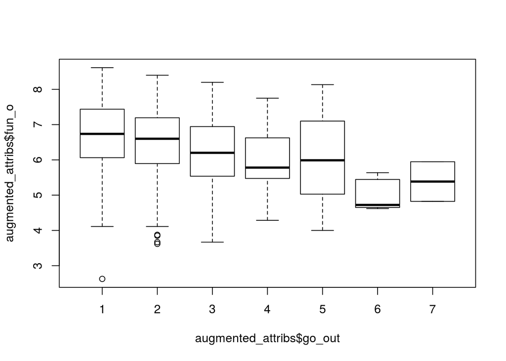

```r
plot(augmented_attribs$fun_o ~ augmented_attribs$go_out)
```

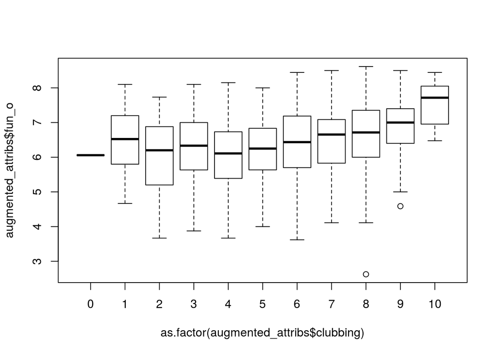

```r
plot(augmented_attribs$fun_o ~ as.factor(augmented_attribs$clubbing))
```

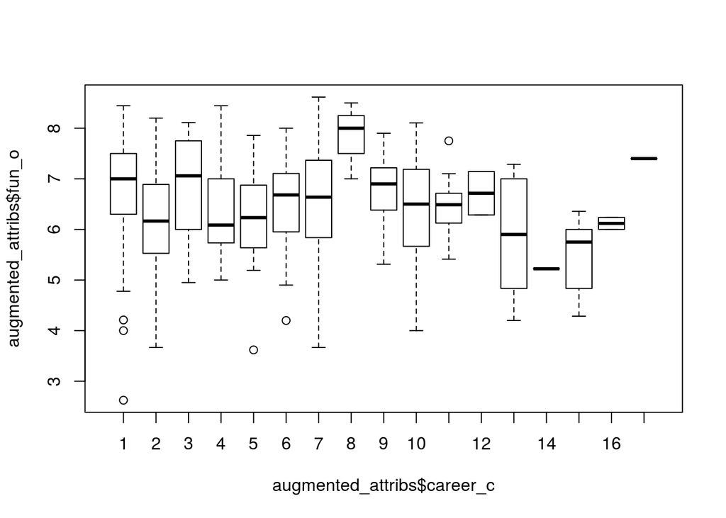

```r
plot(augmented_attribs$fun_o ~ augmented_attribs$career_c)
```

Where should we go from here with this idea? - real estate agents are more fun? (but they showed up as statistically significant with a negative coefficient in the decision model above!) - visually, it is possible that the less you go out (7) the less fun you are - it could be possible that the more important clubbing is to you, the more fun you are

# How accurate is our self-perception?

We see that personality traits like fun and attractiveness are correlated with if your speed date decides to say “yes” to you. What does this mean for us as far as what we think about ourselves? Do we even know how fun/attractive we are to others?

Alternatively, are others able to pick up on our less obvious traits, like sincerity and ambition, in 4 minutes?

plot self ratings vs. avg of trait

```r
#  rate that people decide they like you after the speed date
desirableness <- aggregate(dec_o ~ iid, full_data, mean)

#additional explanitory variables
attractive <- aggregate(attr_o ~ iid, full_data, mean)
sincere <- aggregate(sinc_o ~ iid, full_data, mean)
intelligent <- aggregate( intel_o ~ iid, full_data, mean)
fun <- aggregate( fun_o ~ iid, full_data, mean)
ambitious <- aggregate( amb_o ~ iid, full_data, mean)

personality_attribs <- full_data[, c("iid", "attr3_1", "sinc3_1", "fun3_1", "intel3_1", "amb3_1")]

personality_attribs <- personality_attribs[!duplicated(personality_attribs),]

# binding back together
personality_attribs <- merge(desirableness, personality_attribs,by="iid")

# we end up with three columns of dec_o here
personality_attribs <- Reduce(function(x, y) merge(x, y, all=TRUE), list(attractive, sincere, intelligent, fun, ambitious, personality_attribs, desirableness  ))


attr_lm <- lm(personality_attribs$attr_o ~ personality_attribs$attr3_1)
summary(attr_lm)
```

```
##
## Call:
## lm(formula = personality_attribs$attr_o ~ personality_attribs$attr3_1)
##
## Residuals:
##     Min      1Q  Median      3Q     Max
## -3.8381 -0.7651  0.0491  0.8329  2.6366
##
## Coefficients:
##                             Estimate Std. Error t value Pr(>|t|)
## (Intercept)                  4.44154    0.25427  17.468  < 2e-16 ***
## personality_attribs$attr3_1  0.24712    0.03518   7.024 6.52e-12 ***
## ---
## Signif. codes:  0 '***' 0.001 '**' 0.01 '*' 0.05 '.' 0.1 ' ' 1
##
## Residual standard error: 1.138 on 540 degrees of freedom
##   (9 observations deleted due to missingness)
## Multiple R-squared:  0.08371,    Adjusted R-squared:  0.08202
## F-statistic: 49.33 on 1 and 540 DF,  p-value: 6.521e-12
```

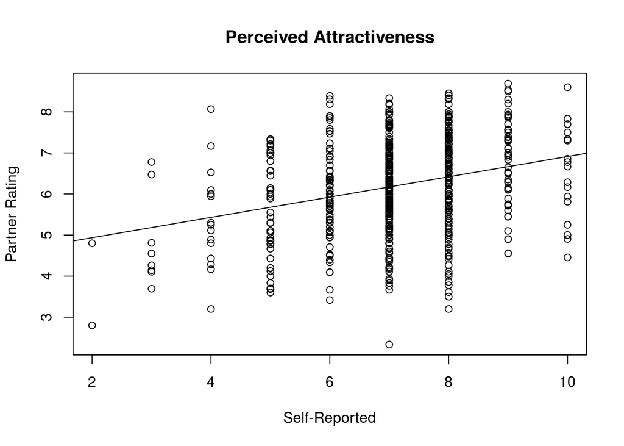

```r
plot(personality_attribs$attr_o ~ personality_attribs$attr3_1, xlab="Self-Reported", ylab = "Partner Rating", main = "Perceived Attractiveness")
abline(attr_lm)
```

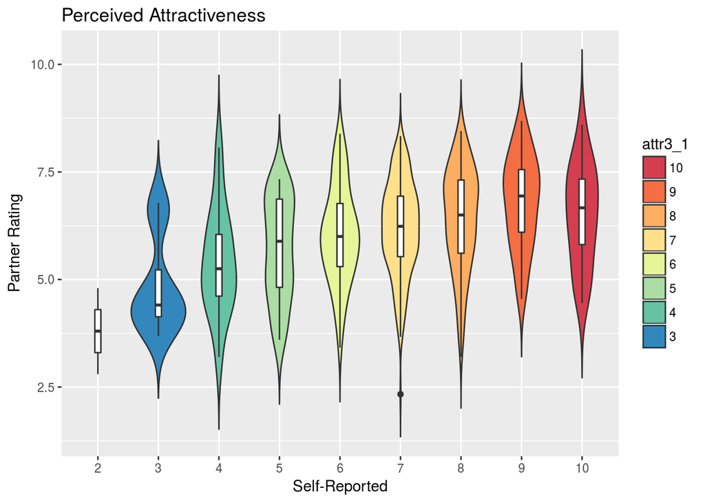

```r
library(ggplot2)
personality_attribs$attr3_1 <- as.factor(personality_attribs$attr3_1)
p <- ggplot(na.omit(personality_attribs), aes(x=attr3_1, y=attr_o, fill=attr3_1)) +
  geom_violin(trim=FALSE)
# plot with median and quartile
p  + geom_boxplot(width=0.1, fill="white") + labs(title="Perceived Attractiveness", x="Self-Reported", y="Partner Rating") + scale_fill_brewer(palette="Spectral", direction = -1) + guides(fill= guide_legend(reverse = TRUE))
```

```r
# is it possible to add the lm to this plot?
```

```r
sinc_lm <- lm(personality_attribs$sinc_o ~ as.numeric(personality_attribs$sinc3_1))
intel_lm <- lm(personality_attribs$intel_o ~ as.numeric(personality_attribs$intel3_1))
fun_lm <- lm(personality_attribs$fun_o ~ as.numeric(personality_attribs$fun3_1))
amb_lm <- lm(personality_attribs$amb_o ~ as.numeric(personality_attribs$amb3_1))

summary(sinc_lm)
```

```
##
## Call:
## lm(formula = personality_attribs$sinc_o ~ as.numeric(personality_attribs$sinc3_1))
##
## Residuals:
##      Min       1Q   Median       3Q      Max
## -3.05351 -0.41264  0.07983  0.49891  1.77983
##
## Coefficients:
##                                          Estimate Std. Error t value
## (Intercept)                              7.265203   0.177344  40.967
## as.numeric(personality_attribs$sinc3_1) -0.005629   0.021099  -0.267
##                                         Pr(>|t|)
## (Intercept)                               <2e-16 ***
## as.numeric(personality_attribs$sinc3_1)     0.79
## ---
## Signif. codes:  0 '***' 0.001 '**' 0.01 '*' 0.05 '.' 0.1 ' ' 1
##
## Residual standard error: 0.693 on 540 degrees of freedom
##   (9 observations deleted due to missingness)
## Multiple R-squared:  0.0001318,  Adjusted R-squared:  -0.00172
## F-statistic: 0.07117 on 1 and 540 DF,  p-value: 0.7897
```

```r
summary(intel_lm)
```

```
##
## Call:
## lm(formula = personality_attribs$intel_o ~ as.numeric(personality_attribs$intel3_1))
##
## Residuals:
##      Min       1Q   Median       3Q      Max
## -2.57062 -0.44042  0.04232  0.45906  1.70438
##
## Coefficients:
##                                          Estimate Std. Error t value
## (Intercept)                               7.14878    0.20778  34.406
## as.numeric(personality_attribs$intel3_1)  0.02968    0.02457   1.208
##                                          Pr(>|t|)
## (Intercept)                                <2e-16 ***
## as.numeric(personality_attribs$intel3_1)    0.228
## ---
## Signif. codes:  0 '***' 0.001 '**' 0.01 '*' 0.05 '.' 0.1 ' ' 1
##
## Residual standard error: 0.6228 on 540 degrees of freedom
##   (9 observations deleted due to missingness)
## Multiple R-squared:  0.002695,   Adjusted R-squared:  0.0008486
## F-statistic: 1.459 on 1 and 540 DF,  p-value: 0.2275
```

```r
summary(fun_lm)
```

```
##
## Call:
## lm(formula = personality_attribs$fun_o ~ as.numeric(personality_attribs$fun3_1))
##
## Residuals:
##     Min      1Q  Median      3Q     Max
## -4.2271 -0.6367  0.0246  0.7546  2.1291
##
## Coefficients:
##                                        Estimate Std. Error t value
## (Intercept)                             5.02305    0.21200  23.693
## as.numeric(personality_attribs$fun3_1)  0.18290    0.02699   6.777
##                                        Pr(>|t|)
## (Intercept)                             < 2e-16 ***
## as.numeric(personality_attribs$fun3_1) 3.23e-11 ***
## ---
## Signif. codes:  0 '***' 0.001 '**' 0.01 '*' 0.05 '.' 0.1 ' ' 1
##
## Residual standard error: 0.9715 on 540 degrees of freedom
##   (9 observations deleted due to missingness)
## Multiple R-squared:  0.07837,    Adjusted R-squared:  0.07667
## F-statistic: 45.92 on 1 and 540 DF,  p-value: 3.23e-11
```

```r
summary(amb_lm)
```

```
##
## Call:
## lm(formula = personality_attribs$amb_o ~ as.numeric(personality_attribs$amb3_1))
##
## Residuals:
##      Min       1Q   Median       3Q      Max
## -2.84567 -0.48655 -0.01689  0.50715  1.90091
##
## Coefficients:
##                                        Estimate Std. Error t value
## (Intercept)                             6.30664    0.14184  44.464
## as.numeric(personality_attribs$amb3_1)  0.06781    0.01822   3.722
##                                        Pr(>|t|)
## (Intercept)                             < 2e-16 ***
## as.numeric(personality_attribs$amb3_1) 0.000219 ***
## ---
## Signif. codes:  0 '***' 0.001 '**' 0.01 '*' 0.05 '.' 0.1 ' ' 1
##
## Residual standard error: 0.757 on 540 degrees of freedom
##   (9 observations deleted due to missingness)
## Multiple R-squared:  0.02501,    Adjusted R-squared:  0.0232
## F-statistic: 13.85 on 1 and 540 DF,  p-value: 0.0002187
```

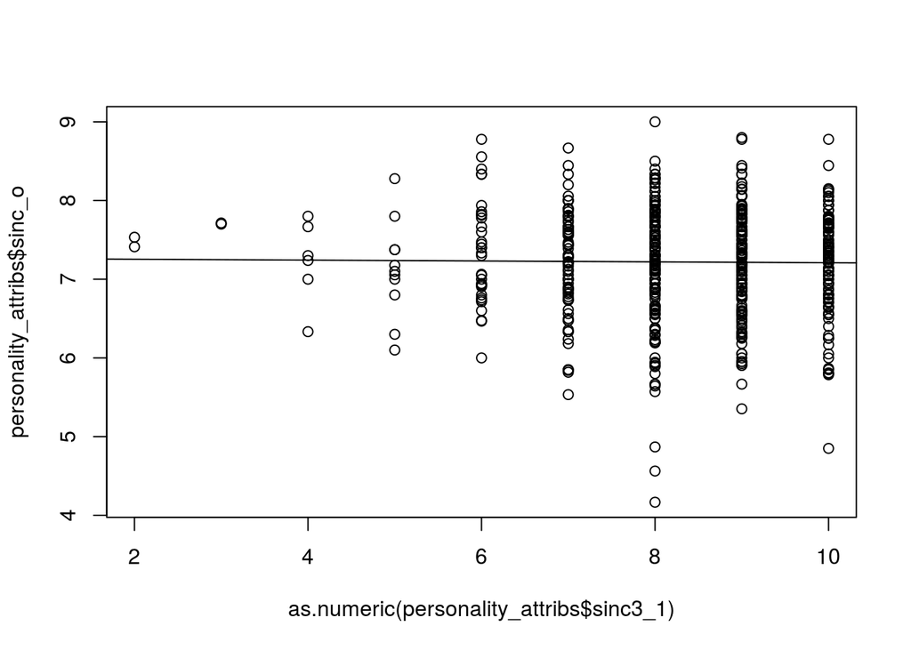

```r
plot(personality_attribs$sinc_o ~ as.numeric(personality_attribs$sinc3_1))
abline(sinc_lm)
```

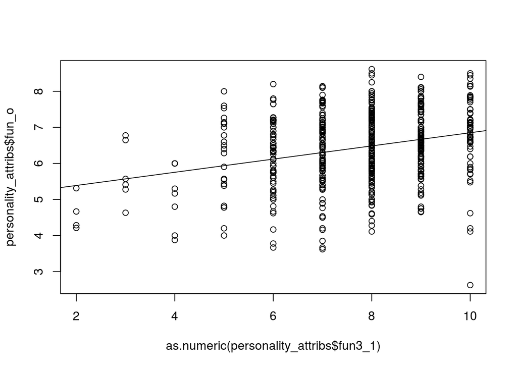

```r
plot(personality_attribs$fun_o ~ as.numeric(personality_attribs$fun3_1))
abline(fun_lm)
```

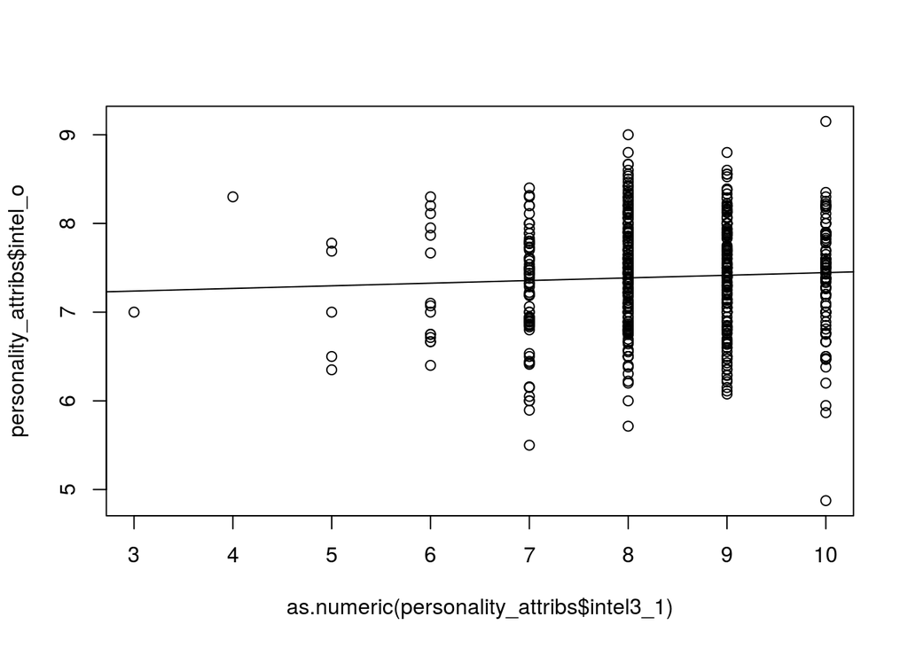

```r
plot(personality_attribs$intel_o ~ as.numeric(personality_attribs$intel3_1))
abline(intel_lm)
```

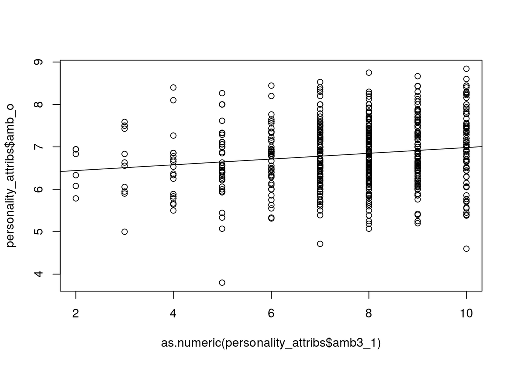

```r
plot(personality_attribs$amb_o ~ as.numeric(personality_attribs$amb3_1))
abline(amb_lm)
```

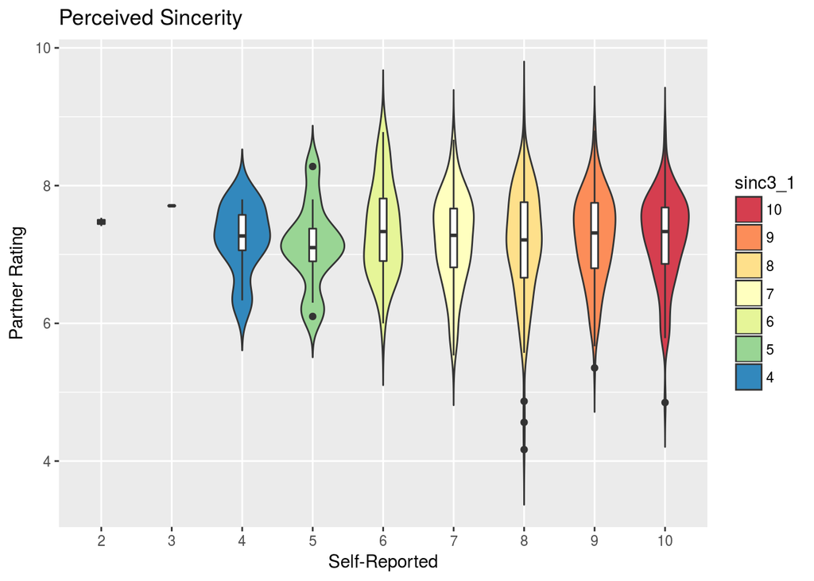

```r
personality_attribs$sinc3_1 <- as.factor(personality_attribs$sinc3_1)
personality_attribs$fun3_1 <- as.factor(personality_attribs$fun3_1)
personality_attribs$intel3_1 <- as.factor(personality_attribs$intel3_1)
personality_attribs$amb3_1 <- as.factor(personality_attribs$amb3_1)

ggplot(na.omit(personality_attribs), aes(x=sinc3_1, y=sinc_o, fill=sinc3_1)) +
  geom_violin(trim=FALSE) + geom_boxplot(width=0.1, fill="white") + labs(title="Perceived Sincerity", x="Self-Reported", y="Partner Rating") + scale_fill_brewer(palette="Spectral", direction = -1) + guides(fill= guide_legend(reverse = TRUE))
```

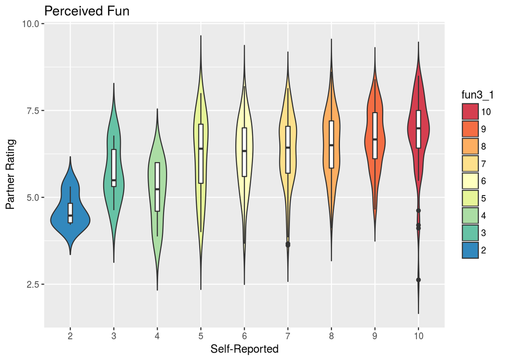

```r
ggplot(na.omit(personality_attribs), aes(x=fun3_1, y=fun_o, fill=fun3_1)) +
  geom_violin(trim=FALSE) + geom_boxplot(width=0.1, fill="white") + labs(title="Perceived Fun", x="Self-Reported", y="Partner Rating") + scale_fill_brewer(palette="Spectral", direction = -1) + guides(fill= guide_legend(reverse = TRUE))
```